# Projekat

Tamara Cicmil

2025-05-02

1. [5pts] Choose at least ve variables from the list above and graphically depict the distribution of these variables for red and for white wines. Compare and interpret the results.

```r
#importing the data

redvine<-read.csv("/home/tamara/Desktop/statistika/winequality-red.csv", sep = ";")
whitevine<-read.csv("/home/tamara/Desktop/statistika/winequality-white.csv", sep = ";")
```

a)alcohol levels

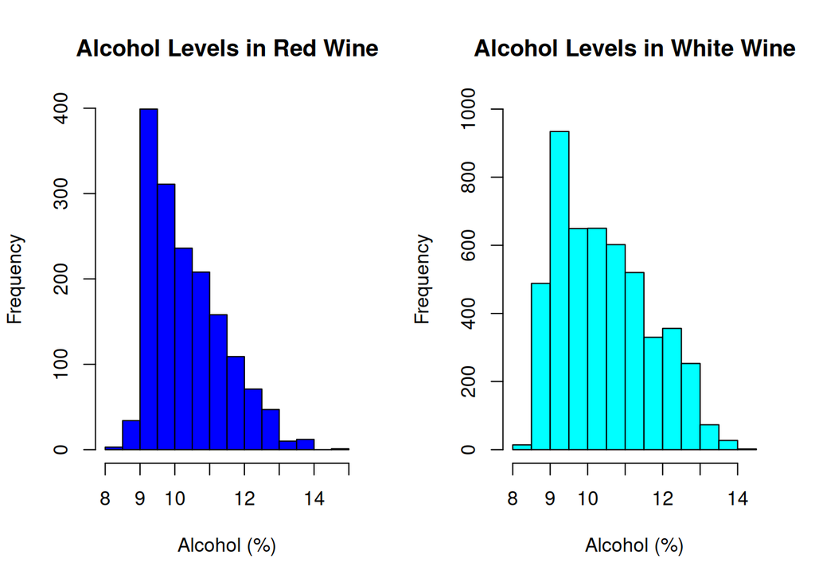

```r
par(mfrow=c(1,2))

hist(redvine$alcohol,
     main = "Alcohol Levels in Red Wine",
     xlab = "Alcohol (%)",
     col = "blue",
     border = "black")
hist(whitevine$alcohol,
     main = "Alcohol Levels in White Wine",
     xlab = "Alcohol (%)", ylim=c(0,1000),
     col = "cyan",
     border = "black")
```

b)residual sugar

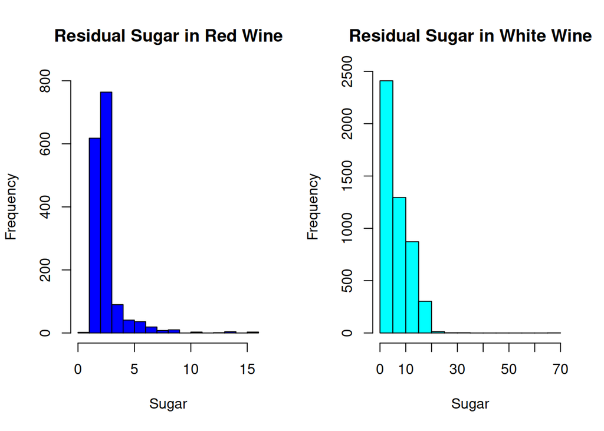

```r
par(mfrow=c(1,2))

hist(redvine$residual.sugar,
     main = "Residual Sugar in Red Wine",
     xlab = "Sugar", ylim=c(0,800),
     col = "blue",
     border = "black")
hist(whitevine$residual.sugar,
     main = "Residual Sugar in White Wine",
     xlab = "Sugar",
     col = "cyan",
     border = "black")
```

Residual sugar levels in red wine range from approximately 0 to 15 g/dm³, with the highest concentration of wines having around 2 g/dm³. In white wine, the range is much wider, extending up to over 60 g/dm³, with the peak still occurring at a low sugar level near 2 g/dm³. The key difference is that the distribution of residual sugar in white wine is flatter and more spread out, meaning there is a larger variety of white wines with higher sugar content, including several very sweet wines. Both distributions are right-skewed, suggesting that the mean residual sugar level is greater than the median due to a long tail of wines with unusually high sugar content.

c)pH

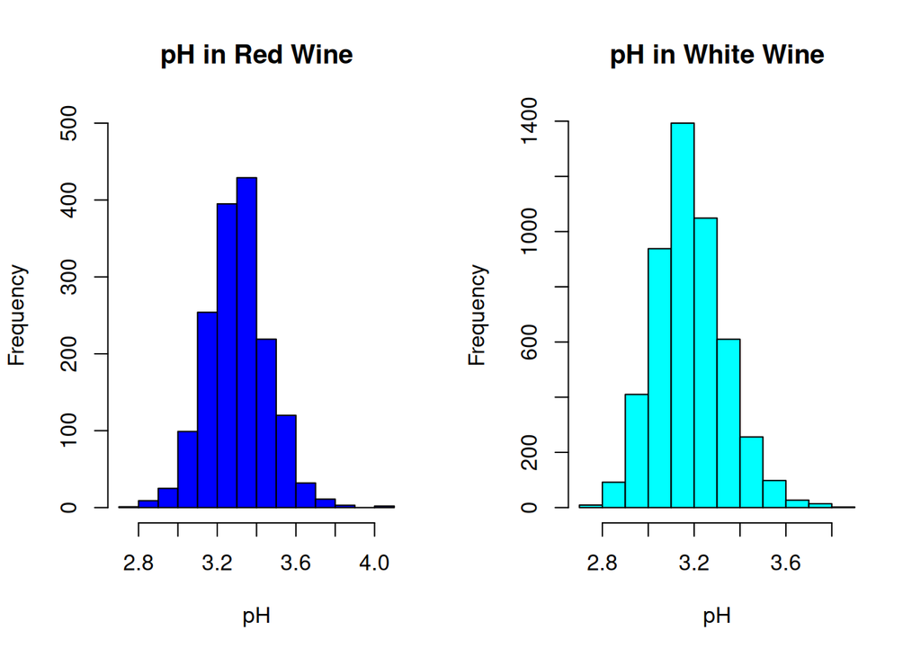

```r
par(mfrow=c(1,2))

hist(redvine$pH,
     main = "pH in Red Wine",
     xlab = "pH", ylim=c(0,500),
     col = "blue",
     border = "black")
hist(whitevine$pH,
     main = "pH in White Wine",
     xlab = "pH",
     col = "cyan",
     border = "black")
```

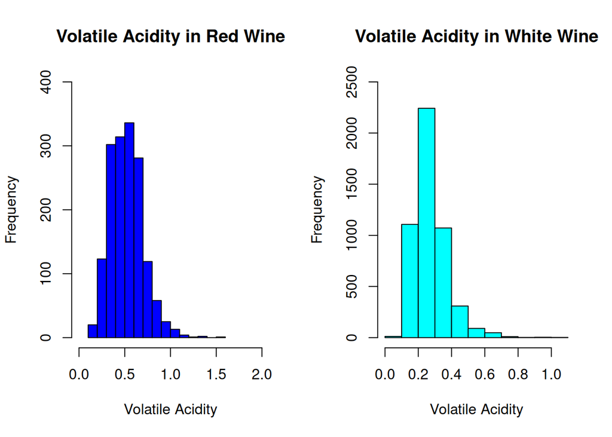

```r
par(mfrow=c(1,2))

hist(redvine$volatile.acidity,
     main = "Volatile Acidity in Red Wine",
     xlab = "Volatile Acidity", ylim=c(0,400),xlim=c(0,2),
     col = "blue",
     border = "black")
hist(whitevine$volatile.acidity,
     main = "Volatile Acidity in White Wine",
     xlab = "Volatile Acidity", ylim=c(0,2500),
     col = "cyan",
     border = "black")
```

Volatile acidity levels in red wines range from approximately 0.2 to 1.5 g/dm³, with the most frequent values occurring around 0.6. In contrast, white wines show lower volatile acidity values overall, ranging from near 0.0 up to 1.0, with a sharp peak around 0.3. The distribution of volatile acidity in white wine is strongly right-skewed, while red wine shows a mildly right-skewed but more symmetric shape. These differences indicate that red wines tend to have higher volatile acidity levels.

5. Chlorides

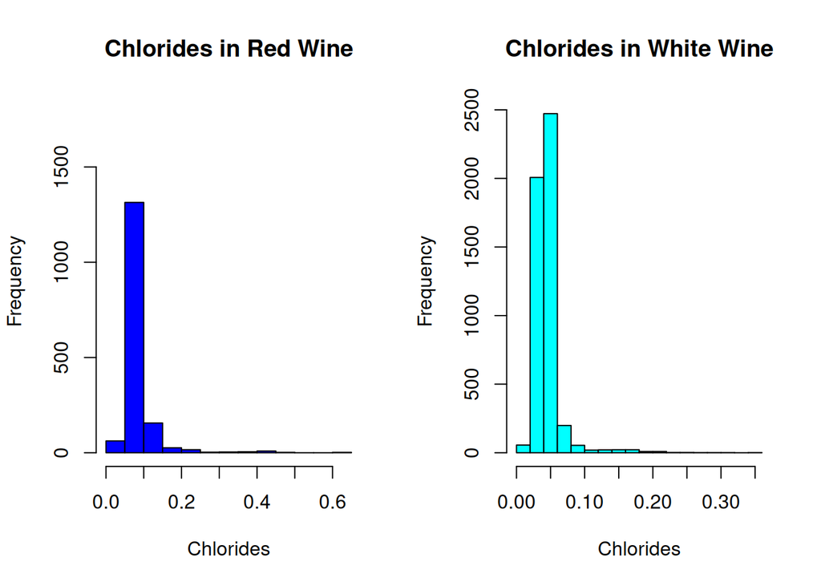

```r
par(mfrow=c(1,2))

hist(redvine$chlorides,
     main = "Chlorides in Red Wine",
     xlab = "Chlorides", ylim=c(0,1800),
     col = "blue",
     border = "black")
hist(whitevine$chlorides,
     main = "Chlorides in White Wine",ylim=c(0,2500),
     xlab = "Chlorides",
     col = "cyan",
     border = "black")
```

Histograms show that levels of chlorides in red vine range up to 0,6 (peak is about 0,1) and in white vine those levels reach 0,3%(peak is around 0,05%). Both distributions are right-skewed, meaning most wines have low chloride levels, but a few wines have unusually high values.

Overall, red wines tend to have higher chloride concentrations compared to white wines, both in terms of range and typical values.

2. [5pts] Calculate the quartiles and draw the box plot for (a) fixed acidity in red wines and (b) fixed acidity in white wines. Compare and interpret the results. Repeat the experiment for residual sugar and density.

fixed acidity:

```r
# calcuklating quantiles,iqr and interval
q1<-quantile(redvine$fixed.acidity, 0.25)
median<-quantile(redvine$fixed.acidity, 0.5)
q3 <- quantile(redvine$fixed.acidity, 0.75)
iqr <- q3 - q1
min(redvine$fixed.acidity)
```

```
## [1] 4.6
```

```r
max(redvine$fixed.acidity)
```

```
## [1] 15.9
```

```r
# Print results
cat("Q1:", q1, "\n")
```

```
## Q1: 7.1
```

```r
cat("Median: ", median,"\n")
```

```
## Median:  7.9
```

```r
cat("Q3:", q3, "\n")
```

```
## Q3: 9.2
```

```r
cat("IQR:", iqr, "\n")
```

```
## IQR: 2.1
```

```r
cat("Interval for outliers: [", q1-1.5*iqr, ",", q3+1.5*iqr,"]", "\n")
```

```
## Interval for outliers: [ 3.95 , 12.35 ]
```

```r
# calcuklating quantiles,iqr and interval
q1<-quantile(whitevine$fixed.acidity, 0.25)
median<-quantile(whitevine$fixed.acidity, 0.5)
q3 <- quantile(whitevine$fixed.acidity, 0.75)
iqr <- q3 - q1
min(whitevine$fixed.acidity)
```

```
## [1] 3.8
```

```r
max(whitevine$fixed.acidity)
```

```
## [1] 14.2
```

```r
# Print results
cat("Q1:", q1, "\n")
```

```
## Q1: 6.3
```

```r
cat("Median: ", median,"\n")
```

```
## Median:  6.8
```

```r
cat("Q3:", q3, "\n")
```

```
## Q3: 7.3
```

```r
cat("IQR:", iqr, "\n")
```

```
## IQR: 1
```

```r
cat("Interval for outliers: [", q1-1.5*iqr, ",", q3+1.5*iqr,"]", "\n")
```

```
## Interval for outliers: [ 4.8 , 8.8 ]
```

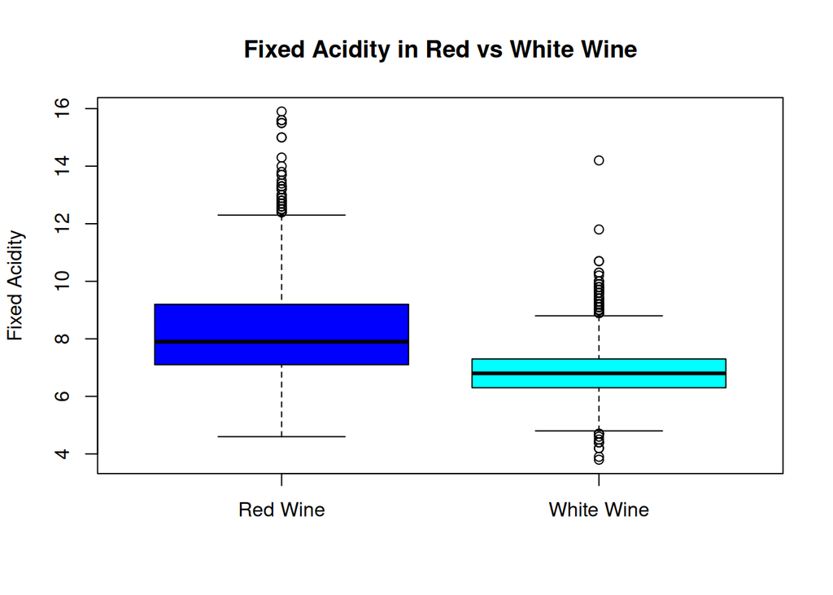

```r
boxplot(redvine$fixed.acidity, whitevine$fixed.acidity,
        names = c("Red Wine", "White Wine"),
        main = "Fixed Acidity in Red vs White Wine",
        ylab = "Fixed Acidity",
        col = c("blue", "cyan"))
```

The boxplots and numerical summaries reveal clear differences in fixed acidity between red and white wines. For red wines, the first quartile (Q1) is 7.1, the third quartile (Q3) is 9.2, and the median is 7.9, resulting in an interquartile range (IQR) of 2.1. The interval for detecting outliers is calculated as [3.95, 12.35], and the observed values range from 4.6 to 15.9, with numerous high outliers above the upper limit. In contrast, white wines have a lower and more consistent distribution. The quartiles are Q1 = 6.3 and Q3 = 7.3, with a median of 6.8 and an IQR of just 1.0. The outlier interval for white wines is narrower, from 4.8 to 8.8, and the values range from 3.8 to 14.2. While both wine types exhibit some extreme values, red wines show a much broader range, a higher central tendency, and more variation overall. This suggests that red wines tend to have both higher and more variable fixed acidity than white wines.

residual sugar:

```r
# calcuklating quantiles,iqr and interval
q1<-quantile(redvine$residual.sugar, 0.25)
median<-quantile(redvine$residual.sugar, 0.5)
q3 <- quantile(redvine$residual.sugar, 0.75)
iqr <- q3 - q1
min(redvine$residual.sugar)
```

```
## [1] 0.9
```

```r
max(redvine$residual.sugar)
```

```
## [1] 15.5
```

```r
# Print results
cat("Q1:", q1, "\n")
```

```
## Q1: 1.9
```

```r
cat("Median: ", median,"\n")
```

```
## Median:  2.2
```

```r
cat("Q3:", q3, "\n")
```

```
## Q3: 2.6
```

```r
cat("IQR:", iqr, "\n")
```

```
## IQR: 0.7
```

```r
cat("Interval for outliers: [", q1-1.5*iqr, ",", q3+1.5*iqr,"]", "\n")
```

```
## Interval for outliers: [ 0.85 , 3.65 ]
```

```r
# calcuklating quantiles,iqr and interval
q1<-quantile(whitevine$residual.sugar, 0.25)
median<-quantile(whitevine$residual.sugar, 0.5)
q3 <- quantile(whitevine$residual.sugar, 0.75)
iqr <- q3 - q1
min(whitevine$residual.sugar)
```

```
## [1] 0.6
```

```r
max(whitevine$residual.sugar)
```

```
## [1] 65.8
```

```r
# Print results
cat("Q1:", q1, "\n")
```

```
## Q1: 1.7
```

```r
cat("Median: ", median,"\n")
```

```
## Median:  5.2
```

```r
cat("Q3:", q3, "\n")
```

```
## Q3: 9.9
```

```r
cat("IQR:", iqr, "\n")
```

```
## IQR: 8.2
```

```r
cat("Interval for outliers: [", q1-1.5*iqr, ",", q3+1.5*iqr,"]", "\n")
```

```
## Interval for outliers: [ -10.6 , 22.2 ]
```

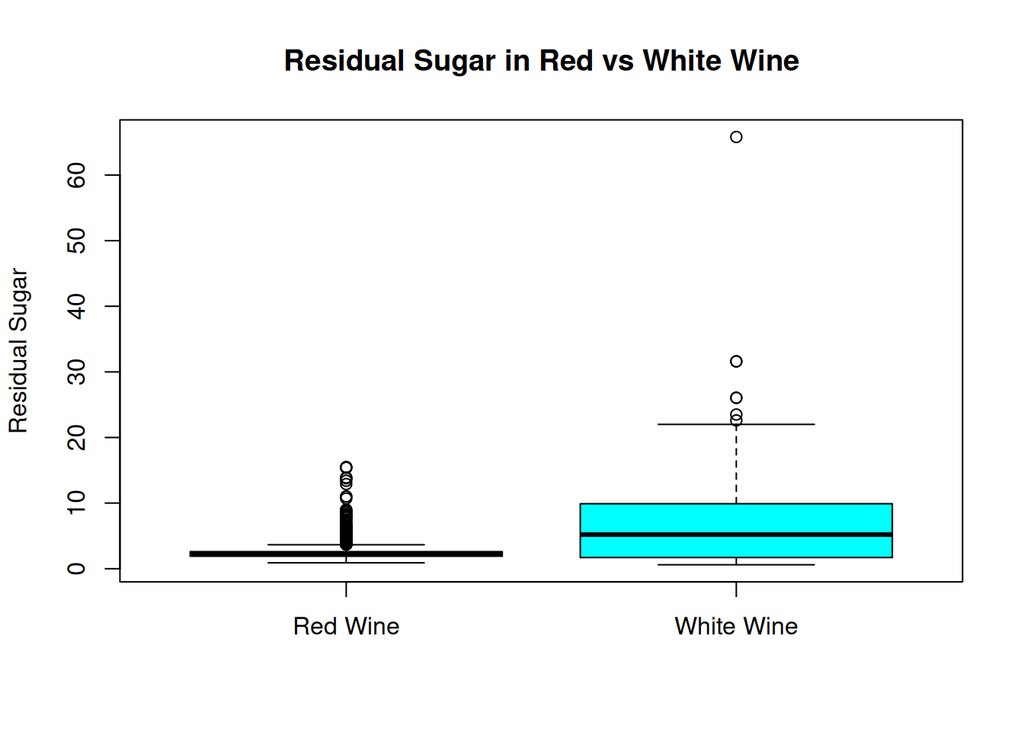

```r
boxplot(redvine$residual.sugar, whitevine$residual.sugar,
        names = c("Red Wine", "White Wine"),
        main = "Residual Sugar in Red vs White Wine",
        ylab = "Residual Sugar",
        col = c("blue", "cyan"))
```

```r
# calcuklating quantiles,iqr and interval
q1<-quantile(redvine$density, 0.25)
median<-quantile(redvine$density, 0.5)
q3 <- quantile(redvine$density, 0.75)
iqr <- q3 - q1
min(redvine$density)
```

```
## [1] 0.99007
```

```r
max(redvine$density)
```

```
## [1] 1.00369
```

```r
# Print results
cat("Q1:", q1, "\n")
```

```
## Q1: 0.9956
```

```r
cat("Median: ", median,"\n")
```

```
## Median:  0.99675
```

```r
cat("Q3:", q3, "\n")
```

```
## Q3: 0.997835
```

```r
cat("IQR:", iqr, "\n")
```

```
## IQR: 0.002235
```

```r
cat("Interval for outliers: [", q1-1.5*iqr, ",", q3+1.5*iqr,"]", "\n")
```

```
## Interval for outliers: [ 0.9922475 , 1.001187 ]
```

```r
# calcuklating quantiles,iqr and interval
q1<-quantile(whitevine$density, 0.25)
median<-quantile(whitevine$density, 0.5)
q3 <- quantile(whitevine$density, 0.75)
iqr <- q3 - q1
min(whitevine$density)
```

```
## [1] 0.98711
```

```r
max(whitevine$density)
```

```
## [1] 1.03898
```

```r
# Print results
cat("Q1:", q1, "\n")
```

```
## Q1: 0.9917225
```

```r
cat("Median: ", median,"\n")
```

```
## Median:  0.99374
```

```r
cat("Q3:", q3, "\n")
```

```
## Q3: 0.9961
```

```r
cat("IQR:", iqr, "\n")
```

```
## IQR: 0.0043775
```

```r
cat("Interval for outliers: [", q1-1.5*iqr, ",", q3+1.5*iqr,"]", "\n")
```

```
## Interval for outliers: [ 0.9851563 , 1.002666 ]
```

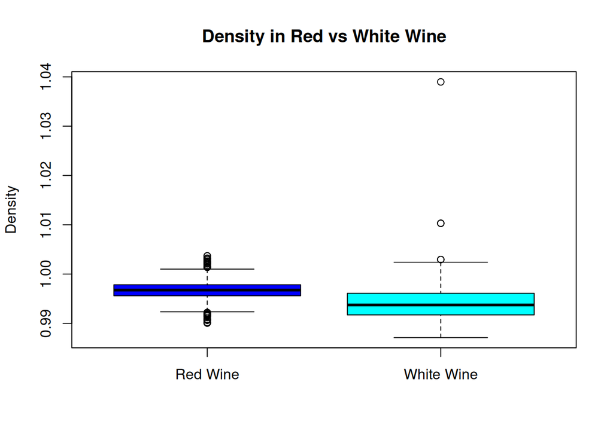

```r
boxplot(redvine$density, whitevine$density,
        names = c("Red Wine", "White Wine"),
        main = "Density in Red vs White Wine",
        ylab = "Density",
        col = c("blue", "cyan"))
```

3. [5pts] We would like to know whether mean fixed acidity of red wines of quality at most 6 is higher than mean fixed acidity of red wines of quality strictly larger than 6. Which statistical test would you use to answer this question and what are your conclusions? What would your answer be in the case of white wines? Repeat the experiment (for both red and white wines) for volatile acidity.

a)red vine both tests

```r
A<- redvine$fixed.acidity[redvine$quality <= 6]
B <-  redvine$fixed.acidity[redvine$quality > 6]

rezultat <- t.test(A, B, alternative = "greater")
print(rezultat)
```

```
##
##  Welch Two Sample t-test
##
## data:  A and B
## t = -4.2635, df = 266.17, p-value = 1
## alternative hypothesis: true difference in means is greater than 0
## 95 percent confidence interval:
##  -0.8463979        Inf
## sample estimates:
## mean of x mean of y
##  8.236831  8.847005
```

H₀: μA ≤ μB (mean fixed acidity of red wines with quality ≤ 6 is not greater than that of quality > 6)

H₁: μA > μB

Since the p-value is 1, which is much greater than 0.05, the result is not statistically significant. Therefore, we fail to reject the null hypothesis. There is no evidence that red wines with quality ≤ 6 have higher mean fixed acidity than those with quality > 6.

```r
A<- redvine$volatile.acidity[redvine$quality <= 6]
B <-  redvine$volatile.acidity[redvine$quality > 6]

rezultat <- t.test(A, B, alternative = "greater")
print(rezultat)
```

```
##
##  Welch Two Sample t-test
##
## data:  A and B
## t = 12.952, df = 325.29, p-value < 2.2e-16
## alternative hypothesis: true difference in means is greater than 0
## 95 percent confidence interval:
##  0.1234724       Inf
## sample estimates:
## mean of x mean of y
## 0.5470224 0.4055300
```

H₁: μA > μB

Since the p-value is less than 2.2e-16, which is much lesser than 0.05, the result is statistically significant. Therefore, we reject the null hypothesis.

b)white wine

```r
A<- whitevine$fixed.acidity[whitevine$quality <= 6]
B <-  whitevine$fixed.acidity[whitevine$quality > 6]

rezultat <- t.test(A, B, alternative = "greater")
print(rezultat)
```

```
##
##  Welch Two Sample t-test
##
## data:  A and B
## t = 6.0401, df = 1856.5, p-value = 9.282e-10
## alternative hypothesis: true difference in means is greater than 0
## 95 percent confidence interval:
##  0.1203734       Inf
## sample estimates:
## mean of x mean of y
##  6.890594  6.725142
```

H₁: μA > μB

Since the p-value is 9.282e-10, which is much lesser than 0.05, the result is statistically significant. Therefore, we reject the null hypothesis.

```r
A<- whitevine$volatile.acidity[whitevine$quality <= 6]
B <-  whitevine$volatile.acidity[whitevine$quality > 6]

rezultat <- t.test(A, B, alternative = "greater")
print(rezultat)
```

```
##
##  Welch Two Sample t-test
##
## data:  A and B
## t = 4.9429, df = 1809.9, p-value = 4.205e-07
## alternative hypothesis: true difference in means is greater than 0
## 95 percent confidence interval:
##  0.01097485        Inf
## sample estimates:
## mean of x mean of y
## 0.2818017 0.2653491
```

H₁: μA > μB

Since the p-value is p-value = 4.205e-07, which is much lesser than 0.05, the result is statistically significant. Therefore, we reject the null hypothesis.

4. [5pts] We would like to know whether there is a correlation between the perceived quality of red wines and the fixed acidity level. Which statistical test would you use to answer this question and what are your conclusions? Furthermore, test the correlation between the perceived quality of red wines and residual sugar levels. Lastly, repeat both tests for white wines and compare the results.

```r
#red wine  quality and fixed acidity
cor.test(redvine$quality, redvine$fixed.acidity)
```

```
##
##  Pearson's product-moment correlation
##
## data:  redvine$quality and redvine$fixed.acidity
## t = 4.996, df = 1597, p-value = 6.496e-07
## alternative hypothesis: true correlation is not equal to 0
## 95 percent confidence interval:
##  0.07548957 0.17202667
## sample estimates:
##       cor
## 0.1240516
```

```r
#red wine quality and residual sugar
cor.test(redvine$quality, redvine$residual.sugar)
```

```
##
##  Pearson's product-moment correlation
##
## data:  redvine$quality and redvine$residual.sugar
## t = 0.5488, df = 1597, p-value = 0.5832
## alternative hypothesis: true correlation is not equal to 0
## 95 percent confidence interval:
##  -0.03531327  0.06271056
## sample estimates:
##        cor
## 0.01373164
```

There is a statistically significant positive correlation between the quality of red wines and their fixed acidity. The correlation coefficient is 0.124, which suggests a weak positive relationship. This means that as the quality of red wines increases, their fixed acidity tends to increase as well, although the strength of the relationship is relatively weak. Since the p-value is much smaller than 0.05, we reject the null hypothesis and conclude that there is indeed a non-zero correlation.

There is no statistically significant correlation between the quality of red wines and their residual sugar levels. The correlation coefficient is very close to 0 (0.014), suggesting a negligible relationship. Since the p-value = 0.5832, which is greater than 0.05, we fail to reject the null hypothesis, indicating no significant linear correlation between these two variables.

```r
#white wine  quality and fixed acidity
cor.test(whitevine$quality, whitevine$fixed.acidity)
```

```
##
##  Pearson's product-moment correlation
##
## data:  whitevine$quality and whitevine$fixed.acidity
## t = -8.005, df = 4896, p-value = 1.48e-15
## alternative hypothesis: true correlation is not equal to 0
## 95 percent confidence interval:
##  -0.14121974 -0.08592991
## sample estimates:
##        cor
## -0.1136628
```

```r
# Red wine correlation between quality and residual sugar
cor.test(whitevine$quality, whitevine$residual.sugar)
```

```
##
##  Pearson's product-moment correlation
##
## data:  whitevine$quality and whitevine$residual.sugar
## t = -6.8603, df = 4896, p-value = 7.724e-12
## alternative hypothesis: true correlation is not equal to 0
## 95 percent confidence interval:
##  -0.12524103 -0.06976101
## sample estimates:
##         cor
## -0.09757683
```

There is a statistically significant negative correlation between the quality of white wines and their fixed acidity. The correlation coefficient is -0.114, indicating a weak negative relationship. As the quality of white wines increases, their fixed acidity tends to decrease slightly. Since the p-value is much smaller than 0.05, we reject the null hypothesis and conclude that there is a significant negative correlation.

There is a statistically significant negative correlation between the quality of white wines and their residual sugar levels. The correlation coefficient is -0.098, suggesting a weak negative relationship. As the quality of white wines increases, their residual sugar levels tend to decrease slightly. The p-value is very small (< 0.05), so we reject the null hypothesis and conclude a significant negative correlation.

5. [5pts] For at least ve of the above mentioned variables check whether the data for red wines is normally distributed. Repeat the analysis for white wines and interpret the results.

A Q-Q plot is a graphical tool used to compare the quantiles of a dataset against the quantiles of a theoretical distribution, typically the normal distribution. If the data points lie approximately along the diagonal line, it suggests that the data follows a normal distribution. A normal distribution is a symmetric, bell-shaped probability distribution where most of the data points cluster around the mean.

red wine:

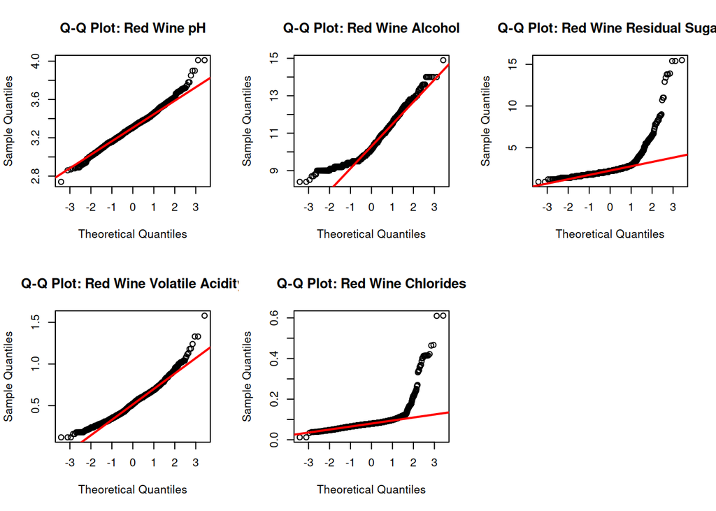

```r
par(mfrow=c(2,3))
#pH
qqnorm(redvine$pH, main = "Q-Q Plot: Red Wine pH")
qqline(redvine$pH, col = "red", lwd = 2)

#alcohol
qqnorm(redvine$alcohol, main = "Q-Q Plot: Red Wine Alcohol")
qqline(redvine$alcohol, col = "red", lwd = 2)

#residual sugar
qqnorm(redvine$residual.sugar, main = "Q-Q Plot: Red Wine Residual Sugar")
qqline(redvine$residual.sugar, col = "red", lwd = 2)

#volatile acidity
qqnorm(redvine$volatile.acidity, main = "Q-Q Plot: Red Wine Volatile Acidity")
qqline(redvine$volatile.acidity, col = "red", lwd = 2)

# chlorides
qqnorm(redvine$chlorides, main = "Q-Q Plot: Red Wine Chlorides")
qqline(redvine$chlorides, col = "red", lwd = 2)
```

pH: Points closely follow the diagonal, approximately normal distribution.

white wine:

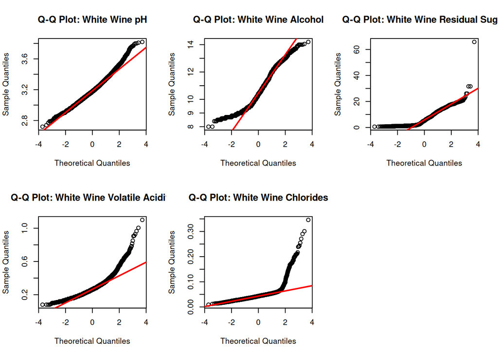

```r
par(mfrow=c(2,3))
#pH
qqnorm(whitevine$pH, main = "Q-Q Plot: White Wine pH")
qqline(whitevine$pH, col = "red", lwd = 2)

#alcohol
qqnorm(whitevine$alcohol, main = "Q-Q Plot: White Wine Alcohol")
qqline(whitevine$alcohol, col = "red", lwd = 2)

#residual sugar
qqnorm(whitevine$residual.sugar, main = "Q-Q Plot: White Wine Residual Sugar")
qqline(whitevine$residual.sugar, col = "red", lwd = 2)

#volatile acidity
qqnorm(whitevine$volatile.acidity, main = "Q-Q Plot: White Wine Volatile Acidity")
qqline(whitevine$volatile.acidity, col = "red", lwd = 2)

#chlorides
qqnorm(whitevine$chlorides, main = "Q-Q Plot: White Wine Chlorides")
qqline(whitevine$chlorides, col = "red", lwd = 2)
```

pH: Slight upward curve at ends.Slight deviation from normality, roughly symmetric.